# test

Background

This week, you are to become familiar with Kaggle.com and use the House Prices Advanced Regression Techniques(https://www.kaggle.com/c/house-prices-advanced-regression-techniques) to an external site. Kaggle competition to hone your Exploratory Data Analysis (EDA) skills. The dependent variable of interest is house prices in Ames, Iowa (‘SalePrice’).

Management/Research Question

In layman’s terms, what is the management/research question of interest, and why would anyone care?

Requirements

You are to conduct EDA on the dataset as follows.

Provide appropriate descriptive statistics and visualizations to help understand the marginal distribution of the dependent variable. Investigate missing data and outliers. Investigate at least three potential predictors of the dependent variable and provide appropriate graphs / statistics to demonstrate the relationships. Engage in feature creation by splitting, merging, or otherwise generating a new predictor.

Using the dependent variable, perform both min-max and standard scaling in Python. (Some methods we will learn in this course (trees and random forests) are unaffected by monotonic transformations of the explanatory variables. Others (SVMs and neural networks) are very much affected by scaling and usually perform better when all explanatory variables have the same scale. It is often best to use scaling methods that preserve the shape of the distribution. But if there are extreme outliers or heavily skewed distributions, then log or normalizing transformations may be warranted.)

```python
import pandas as pd

train = pd.read_csv('train.csv')
train.head()
```

|  | Id | MSSubClass | MSZoning | LotFrontage | LotArea | Street | Alley | LotShape | LandContour | Utilities | ... | PoolArea | PoolQC | Fence | MiscFeature | MiscVal | MoSold | YrSold | SaleType | SaleCondition | SalePrice |
| --- | --- | --- | --- | --- | --- | --- | --- | --- | --- | --- | --- | --- | --- | --- | --- | --- | --- | --- | --- | --- | --- |
| 0 | 1 | 60 | RL | 65.0 | 8450 | Pave | NaN | Reg | Lvl | AllPub | ... | 0 | NaN | NaN | NaN | 0 | 2 | 2008 | WD | Normal | 208500 |
| 1 | 2 | 20 | RL | 80.0 | 9600 | Pave | NaN | Reg | Lvl | AllPub | ... | 0 | NaN | NaN | NaN | 0 | 5 | 2007 | WD | Normal | 181500 |
| 2 | 3 | 60 | RL | 68.0 | 11250 | Pave | NaN | IR1 | Lvl | AllPub | ... | 0 | NaN | NaN | NaN | 0 | 9 | 2008 | WD | Normal | 223500 |
| 3 | 4 | 70 | RL | 60.0 | 9550 | Pave | NaN | IR1 | Lvl | AllPub | ... | 0 | NaN | NaN | NaN | 0 | 2 | 2006 | WD | Abnorml | 140000 |
| 4 | 5 | 60 | RL | 84.0 | 14260 | Pave | NaN | IR1 | Lvl | AllPub | ... | 0 | NaN | NaN | NaN | 0 | 12 | 2008 | WD | Normal | 250000 |

5 rows × 81 columns

```python
train.shape
```

```
(1460, 81)
```

```python
# The dependent variable of interest is house prices in Ames, Iowa (‘SalePrice’).
sale_price = train['SalePrice']

sale_price
```

```
0       208500
1       181500
2       223500
3       140000
4       250000
         ...
1455    175000
1456    210000
1457    266500
1458    142125
1459    147500
Name: SalePrice, Length: 1460, dtype: int64
```

```python
# Provide appropriate descriptive statistics and visualizations to help understand the marginal distribution of the dependent variable.

# Descriptive statistics
sale_price.describe()
```

```
count      1460.000000
mean     180921.195890
std       79442.502883
min       34900.000000
25%      129975.000000
50%      163000.000000
75%      214000.000000
max      755000.000000
Name: SalePrice, dtype: float64
```

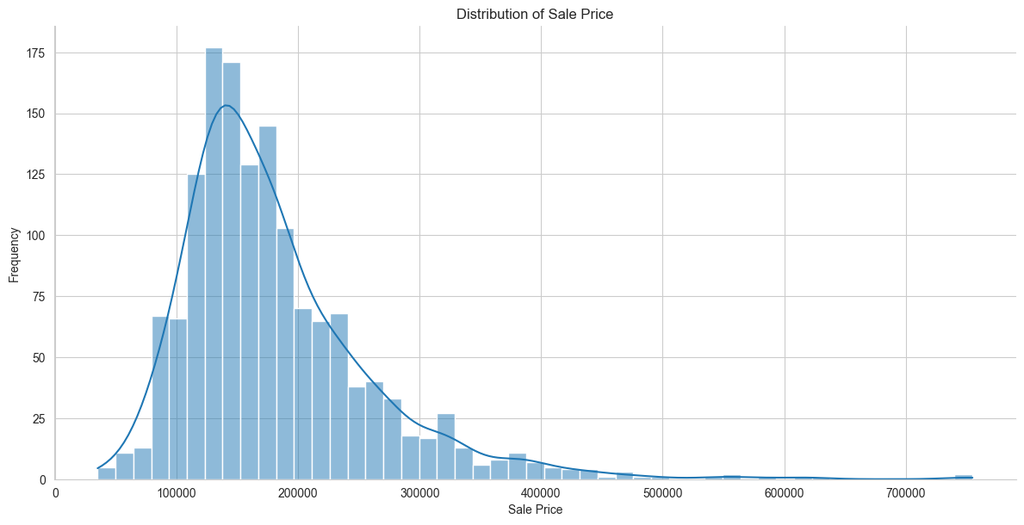

```python
# Visualizations
import matplotlib.pyplot as plt
import seaborn as sns

sns.set_style("whitegrid")

sns.displot(sale_price, kde=True, height=6, aspect=2)
plt.xlabel("Sale Price")
plt.ylabel("Frequency")
plt.title("Distribution of Sale Price")
plt.show()
```

```python
# Engage in feature creation by splitting, merging, or otherwise generating a new predictor.

# Create a new feature called 'TotalSF' by adding the square footage of all floors and the basement together
train["TotalSF"] = train["1stFlrSF"] + train["2ndFlrSF"] + train["TotalBsmtSF"]


# Create a new feature called 'TotalBath' by adding the number of full bathrooms and half bathrooms together
train["TotalBath"] = train["FullBath"] + train["HalfBath"]


# Create a new feature called 'TotalPorchSF' by adding the square footage of all porches together
train["TotalPorchSF"] = (
    train["OpenPorchSF"]
    + train["EnclosedPorch"]
    + train["3SsnPorch"]
    + train["ScreenPorch"]
)

# Create a new feature called 'TotalOutsideSF' by adding the square footage of all porches together
train["TotalOutsideSF"] = (
    train["WoodDeckSF"]
    + train["OpenPorchSF"]
    + train["EnclosedPorch"]
    + train["3SsnPorch"]
    + train["ScreenPorch"]
)

# drop the old features
train.drop(
    [
        "1stFlrSF",
        "2ndFlrSF",
        "TotalBsmtSF",
        "FullBath",
        "HalfBath",
        "OpenPorchSF",
        "EnclosedPorch",
        "3SsnPorch",
        "ScreenPorch",
        "WoodDeckSF",
    ],
    axis=1,
    inplace=True,
)
```

```python
# Investigate missing data and outliers.

missing = train.isnull().sum()
missing_cols = missing[missing > 0]
percent = (train.isnull().sum()/train.isnull().count())
missing = pd.concat([missing, percent], axis=1, keys=['Total', 'Percent'])
missing = missing[missing['Total'] > 0]
missing.head(-1).sort_values(ascending=False , by='Percent')
```

|  | Total | Percent |
| --- | --- | --- |
| PoolQC | 1453 | 0.995205 |
| Alley | 1369 | 0.937671 |
| Fence | 1179 | 0.807534 |
| MasVnrType | 872 | 0.597260 |
| FireplaceQu | 690 | 0.472603 |
| LotFrontage | 259 | 0.177397 |
| GarageType | 81 | 0.055479 |
| GarageYrBlt | 81 | 0.055479 |
| GarageFinish | 81 | 0.055479 |
| GarageQual | 81 | 0.055479 |
| GarageCond | 81 | 0.055479 |
| BsmtExposure | 38 | 0.026027 |
| BsmtFinType2 | 38 | 0.026027 |
| BsmtFinType1 | 37 | 0.025342 |
| BsmtCond | 37 | 0.025342 |
| BsmtQual | 37 | 0.025342 |
| MasVnrArea | 8 | 0.005479 |
| Electrical | 1 | 0.000685 |

`train` dataframe has 1460 rows, 81 columns. It is safe to assume that columns having more than 584 missing values (40% of the length) are not useful for our analysis. Columns to be excluded are as follows:

```python
# drop columns with more than 40% missing values

missing_columns = missing[missing['Percent'] > 0.4].index
train = train.drop(columns=missing_columns)
train.shape
```

```
(1460, 69)
```

we can futhrer drop columns which have:

1. if the variance of the column is less than 0.01, it is almost a constant column.
2. if the column is highly imbalnced, such as top value consists of more than 90% of the column.

```python
def should_drop(series):

    # Very low variance
    if series.var() < 0.01:
        return True
    # Top value accounts for more than 90%
    if series.value_counts(normalize=True).iloc[0] > 0.9:
        return True

    return False


to_drop = []
for col in train.columns:
    if train[col].dtype == 'object':
        continue
    if should_drop(train[col]):
        to_drop.append(col)

train.drop(to_drop, axis=1, inplace=True)
print(f"Dropped {len(to_drop)} columns with bad distributions.")
for col in to_drop:
    print(col)
```

```
Dropped 5 columns with bad distributions.
LowQualFinSF
BsmtHalfBath
KitchenAbvGr
PoolArea
MiscVal
```

```python
train.shape
```

```
(1460, 64)
```

```python
import pandas as pd

# Subset to just numeric columns
numeric_cols = train.select_dtypes(include=["int", "float"])


# Function to detect outliers
def detect_outliers(series):
    cutoff = 3
    lower, upper = (
        series.mean() - cutoff * series.std(),
        series.mean() + cutoff * series.std(),
    )
    outliers = series[(series < lower) | (series > upper)]
    return outliers


# Identify outliers for each numeric column
outliers = {}
for col in numeric_cols:
    outliers[col] = detect_outliers(numeric_cols[col])

# Wrap in dictionary to dataframe
outliers = pd.DataFrame(outliers)

print(f"Identified {outliers.shape[0]} numeric outliers")

# collect indices
outlier_indices = []
for col in numeric_cols:
    outlier_indices.extend(outliers[col].index)


# Drop outliers
train = train.drop(outlier_indices)

print(f"{len(train)} rows remaining")
```

```
Identified 231 numeric outliers
1229 rows remaining
```

```python
train.shape
```

```
(1229, 64)
```

```python
num_features = train.drop(columns='Id').select_dtypes(include=['int', 'float'])
total_num_features = len(num_features.columns)
total_num_features
```

```
26
```

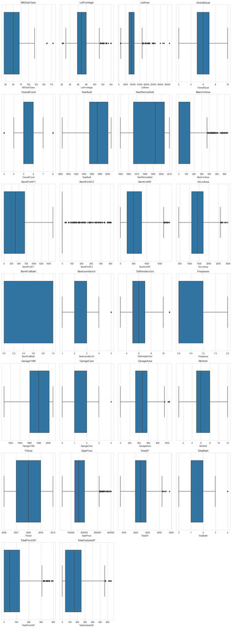

```python
fig, axes = plt.subplots(nrows=total_num_features // 4 + 1, ncols=4, figsize=(15, 40))
axes = axes.flatten()
for i, col in enumerate(num_features.columns):
    if i < total_num_features:
        sns.boxplot(x=train[col], ax=axes[i])
        axes[i].set_title(f"{col}")


for i in range(len(num_features.columns), len(axes)):
    fig.delaxes(axes[i])


plt.tight_layout()

plt.show()
```

```python
# As the data contains columns having string values, we need to convert them into numerical values using LabelEncoder


from sklearn.preprocessing import LabelEncoder

le = LabelEncoder()
# Apply LabelEncoder to each column containing string values
for col in train.select_dtypes(include=["object"]).columns:
    train[col] = le.fit_transform(train[col].astype(str))

# Check the transformed dataframe
train.head()
```

|  | Id | MSSubClass | MSZoning | LotFrontage | LotArea | Street | LotShape | LandContour | Utilities | LotConfig | ... | PavedDrive | MoSold | YrSold | SaleType | SaleCondition | SalePrice | TotalSF | TotalBath | TotalPorchSF | TotalOutsideSF |
| --- | --- | --- | --- | --- | --- | --- | --- | --- | --- | --- | --- | --- | --- | --- | --- | --- | --- | --- | --- | --- | --- |
| 0 | 1 | 60 | 3 | 65.0 | 8450 | 1 | 3 | 3 | 0 | 4 | ... | 2 | 2 | 2008 | 8 | 4 | 208500 | 2566 | 3 | 61 | 61 |
| 1 | 2 | 20 | 3 | 80.0 | 9600 | 1 | 3 | 3 | 0 | 2 | ... | 2 | 5 | 2007 | 8 | 4 | 181500 | 2524 | 2 | 0 | 298 |
| 2 | 3 | 60 | 3 | 68.0 | 11250 | 1 | 0 | 3 | 0 | 4 | ... | 2 | 9 | 2008 | 8 | 4 | 223500 | 2706 | 3 | 42 | 42 |
| 3 | 4 | 70 | 3 | 60.0 | 9550 | 1 | 0 | 3 | 0 | 0 | ... | 2 | 2 | 2006 | 8 | 0 | 140000 | 2473 | 1 | 307 | 307 |
| 4 | 5 | 60 | 3 | 84.0 | 14260 | 1 | 0 | 3 | 0 | 2 | ... | 2 | 12 | 2008 | 8 | 4 | 250000 | 3343 | 3 | 84 | 276 |

5 rows × 64 columns

```python
# Investigate at least three potential predictors of the dependent variable and provide appropriate graphs / statistics to demonstrate the relationships.

# Correlation matrix
corr = train.corr()

# choose the top 10 features correlated with SalePrice
top_10_corr = corr['SalePrice'].sort_values(ascending=False).head(11)
top_10_corr
```

```
SalePrice       1.000000
TotalSF         0.816789
OverallQual     0.807844
GrLivArea       0.710140
GarageCars      0.658559
GarageArea      0.642250
YearBuilt       0.615739
TotalBath       0.578539
YearRemodAdd    0.558530
GarageYrBlt     0.552628
TotRmsAbvGrd    0.517949
Name: SalePrice, dtype: float64
```

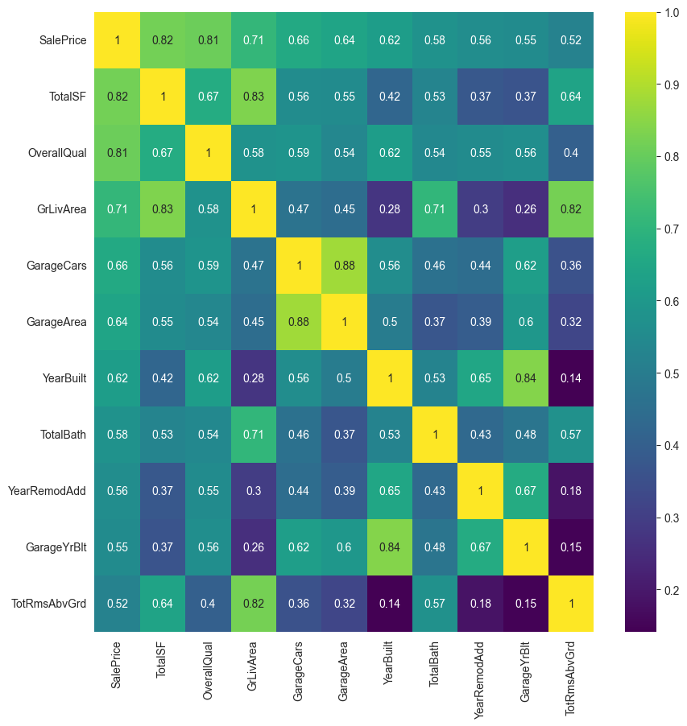

```python
# Heatmap

corr = train[top_10_corr.index].corr()
corr

plt.figure(figsize=(10, 10))
sns.heatmap(corr, annot=True, cmap="viridis")
plt.show()
```

Based on the correlation, let's choose those three featues as potential predictors of the dependent variable

- TotalSF
- OverallQual
- GrLivArea

```python
train = train[[
    'TotalSF',
    'OverallQual',
    'GrLivArea',
    'SalePrice'
]]
```

```python
# Using the dependent variable, perform both min-max and standard scaling in Python.
# (Some methods we will learn in this course (trees and random forests) are unaffected by monotonic transformations of the explanatory variables. Others (SVMs and neural networks) are very much affected by scaling and usually perform better when all explanatory variables have the same scale. It is often best to use scaling methods that preserve the shape of the distribution. But if there are extreme outliers or heavily skewed distributions, then log or normalizing transformations may be warranted.)

# Min-max scaling
from sklearn.preprocessing import MinMaxScaler

scaler = MinMaxScaler()
scaled = scaler.fit_transform(train)
scaled = pd.DataFrame(scaled, columns=train.columns)

scaled.head()
```

|  | TotalSF | OverallQual | GrLivArea | SalePrice |
| --- | --- | --- | --- | --- |
| 0 | 0.448603 | 0.625 | 0.500787 | 0.471198 |
| 1 | 0.438396 | 0.500 | 0.324409 | 0.397739 |
| 2 | 0.482625 | 0.625 | 0.530709 | 0.512009 |
| 3 | 0.426002 | 0.625 | 0.503543 | 0.284829 |
| 4 | 0.637424 | 0.750 | 0.692913 | 0.584108 |

```python
# Standard scaling
from sklearn.preprocessing import StandardScaler

scaler = StandardScaler()
scaled = scaler.fit_transform(train)
scaled = pd.DataFrame(scaled, columns=train.columns)

scaled.head()
```

|  | TotalSF | OverallQual | GrLivArea | SalePrice |
| --- | --- | --- | --- | --- |
| 0 | 0.175838 | 0.755927 | 0.622446 | 0.596150 |
| 1 | 0.112085 | -0.022159 | -0.418111 | 0.162358 |
| 2 | 0.388349 | 0.755927 | 0.798969 | 0.837145 |
| 3 | 0.034670 | 0.755927 | 0.638705 | -0.504397 |
| 4 | 1.355274 | 1.534013 | 1.755910 | 1.262904 |

```python
# Using the dependent variable, perform both min-max and standard scaling in Python.
```